# COPDgene variables

Andrey Ziyatdinov

2017-03-15

# 1 Questions

- Negative `finalGold` values (-1, -2)?
- Age variable `Age_Enroll`?
- Covariates for all 6 phenotypes
- Related individuals?

# 2 Variable Names

## 2.1 Traits

| Phenotype | Used variables | Other variables |
| --- | --- | --- |
| COPD status | `finalGold` |  |
| FEV1 | `FEV1pp_utah` | `FEV1_utah`, `pre_FEV1`, `deltaFEV1`, `BDR_pct_FEV1` |
| FVC | `FVCpp_utah` | `FVC_utah`, `pre_FVC`, `deltaFVC`, `BDR_pct_FVC` |
| FEV1/FVC ratio | `FEV1_FVC_utah` | `pre_FEV1_FVC` |
| Percent emphysema | `pctEmph_Slicer` |  |
| TLC | `TLCpp_race_adjusted` |  |

Comments from Michael:

- COPD status, `finalGold`: 0 means control; finalgold 2,3,4 means case
- FEV1, `FEV1_utah`, `FEV1pp_utah`: This needs adjustment for age, sex, height. Percent predicted is FEV1pp_utah
- FVC, `FVC_utah` , `FVCpp_utah`: these are post-bronchodilator
- Percent emphysema, `pctEmph_Slicer`: We usually log this value and include scanner and current smoking (smokcignow) as covariates.
- TLC, `TLCpp_race_adjusted`: this is already adjusted for race, and body size

## 2.2 Covariates

| Covariate | Used variable | Other variables |
| --- | --- | --- |
| age | `Age_Enroll` | `CopdAge` |
| gender | `gender` |  |
| center | `ccenter` |  |
| packs/year | `ATS_PackYears` |  |
| ever smoked | `EverSmokedCig` |  |
| smoking now | `SmokCigNow` |  |
| height | `Height_CM` |  |

# 3 Models

## 3.1 Covariate list

| trait | covlist |
| --- | --- |
| finalGold |  |
| FEV1pp_utah | Age_Enroll, gender, Height_CM |
| FVCpp_utah |  |
| FEV1_FVC_utah |  |
| log_pctEmph_Slicer | SmokCigNow, scanner |
| TLCpp_race_adjusted |  |

# 4 Missing data

## 4.1 Missing data in phenotypes

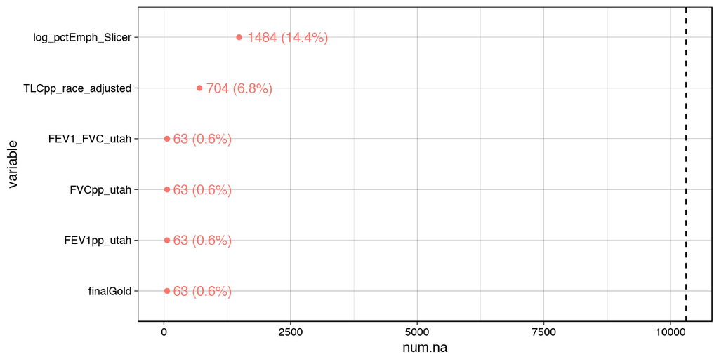

## 4.2 Missing data in covariates

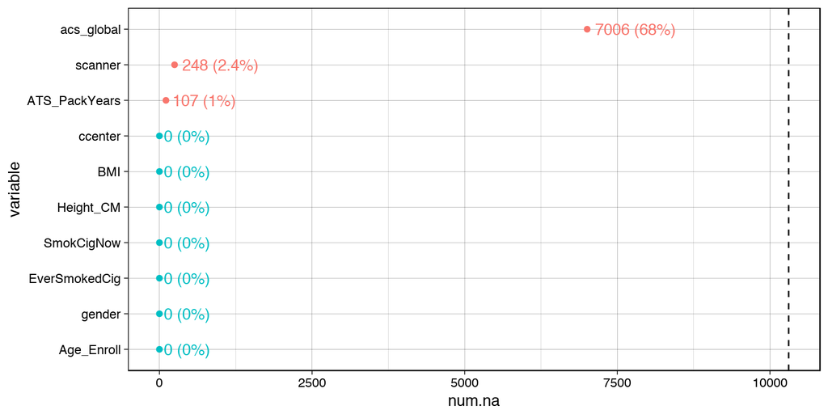

# 5 Correlations (spearman)

- Spearman correlations are computed.
- No special treatment for `finalGold` variable.

The traits are ordered by the hierarchical clustering.

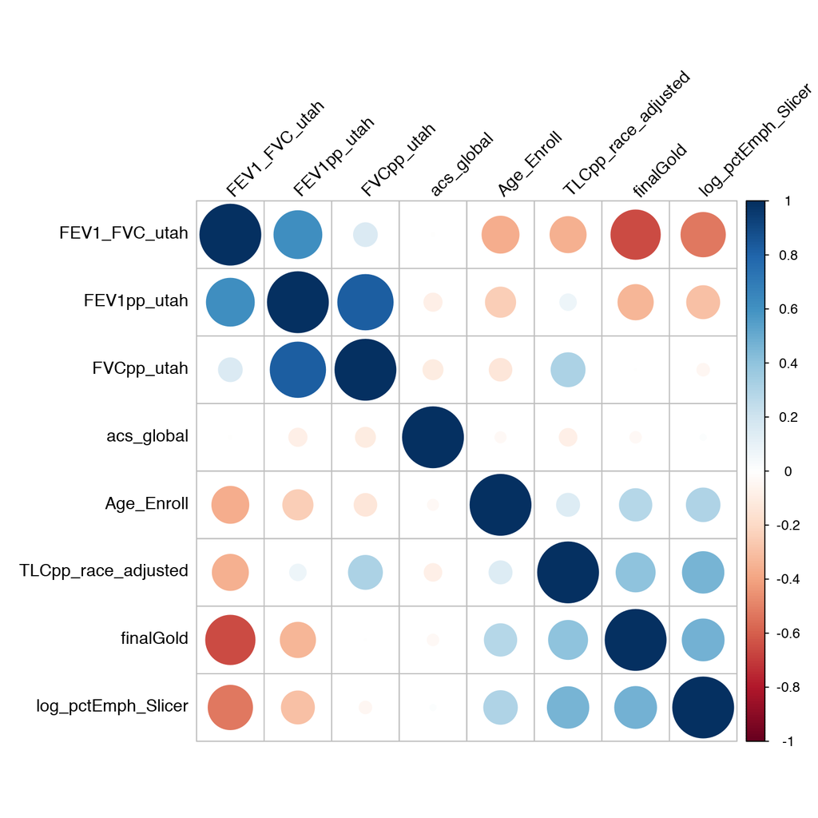

## 5.1 Correlations + more details

Traits’ order:

- Age_Enroll
- acs_global
- finalGold
- FEV1pp_utah
- FVCpp_utah
- FEV1_FVC_utah
- log_pctEmph_Slicer
- TLCpp_race_adjusted

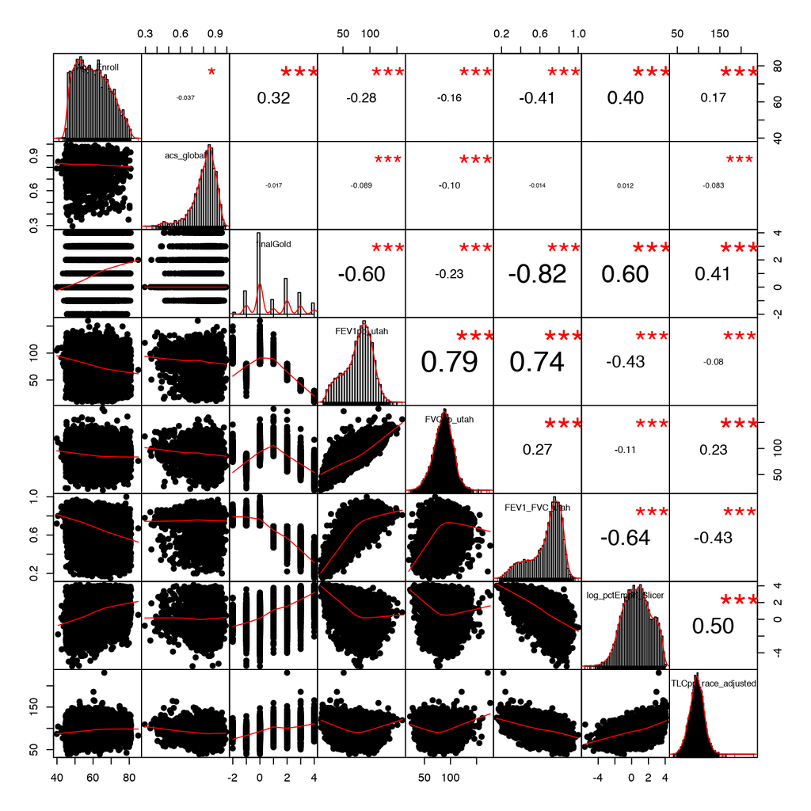

# 6 Kumar’s model

Model:

```
FEV1pp_utah ~ acs_global + gender + c_Age_Enroll + c_log_ATS_PackYears +
    c_Height_CM + c_Height_CM2 + c_BMI + (1 | ccenter)
```

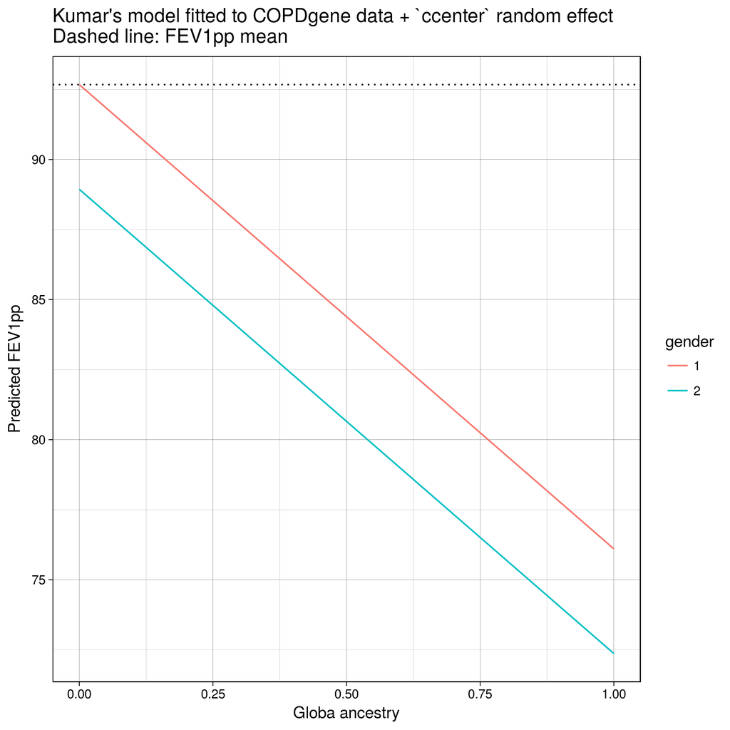

Effects:

```
Random effects:
        Chi.sq Chi.DF elim.num p.value
ccenter 152.59      1     kept < 1e-07

Fixed effects:
                         Sum Sq     Mean Sq NumDF   DenDF  F.value elim.num
c_Height_CM2           175.9973    175.9973     1 3236.23   0.3659        1
c_log_ATS_PackYears    758.1333    758.1333     1 3248.19   1.5765        2
acs_global            9177.8146   9177.8146     1 3253.11  19.0816     kept
gender                5919.8248   5919.8248     1 3246.76  12.3079     kept
c_Age_Enroll        158293.7758 158293.7758     1 3250.23 329.1092     kept
c_Height_CM          12530.3717  12530.3717     1 3242.45  26.0519     kept
c_BMI                 3938.0900   3938.0900     1 3247.49   8.1877     kept
                    Pr(>F)
c_Height_CM2        0.5453
c_log_ATS_PackYears 0.2094
acs_global               0
gender              0.0005
c_Age_Enroll        <1e-07
c_Height_CM              0
c_BMI               0.0042
```

# 7 Misc

## 7.1 Multi-category covariates

### 7.1.1 Center

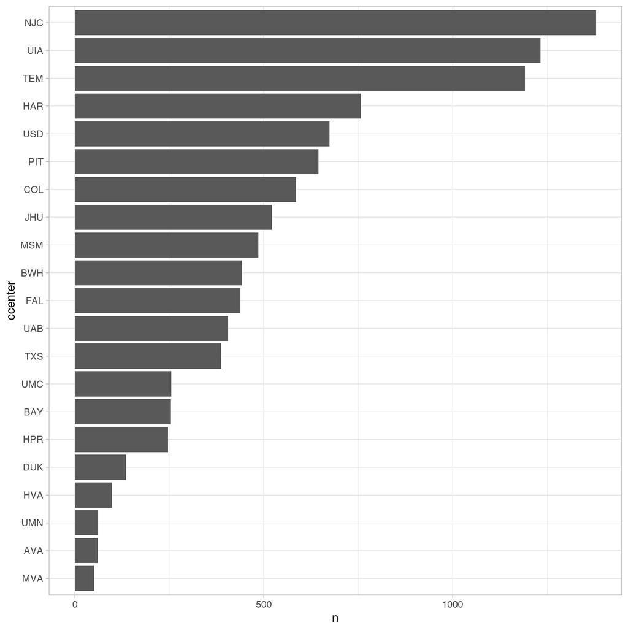

### 7.1.2 Center & FEV1

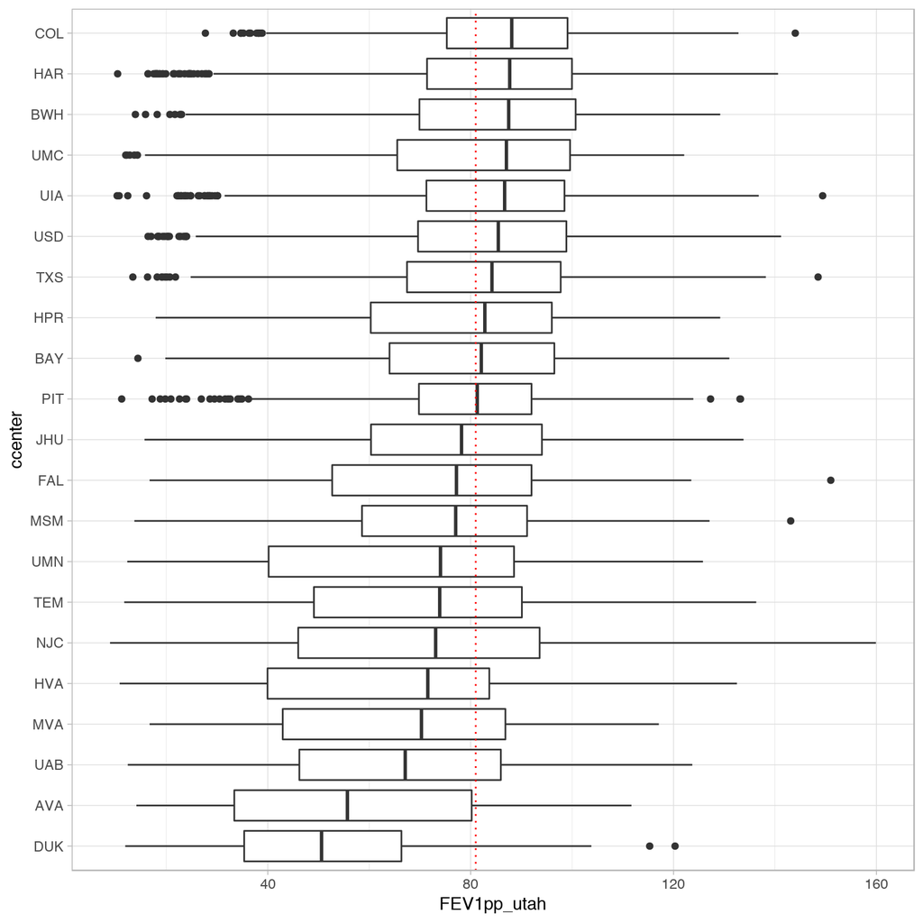

### 7.1.3 Scanner

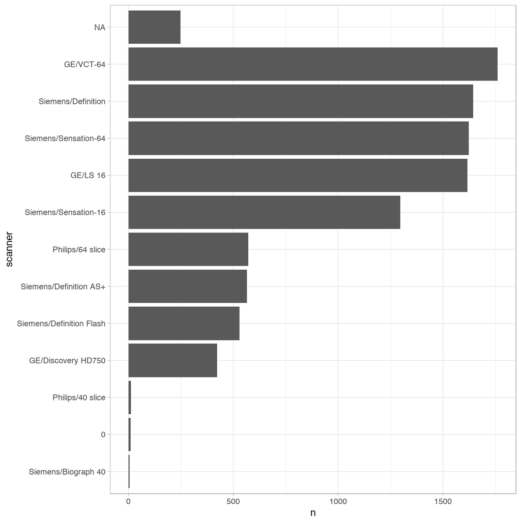

### 7.1.4 Scanner & Percent emphysema

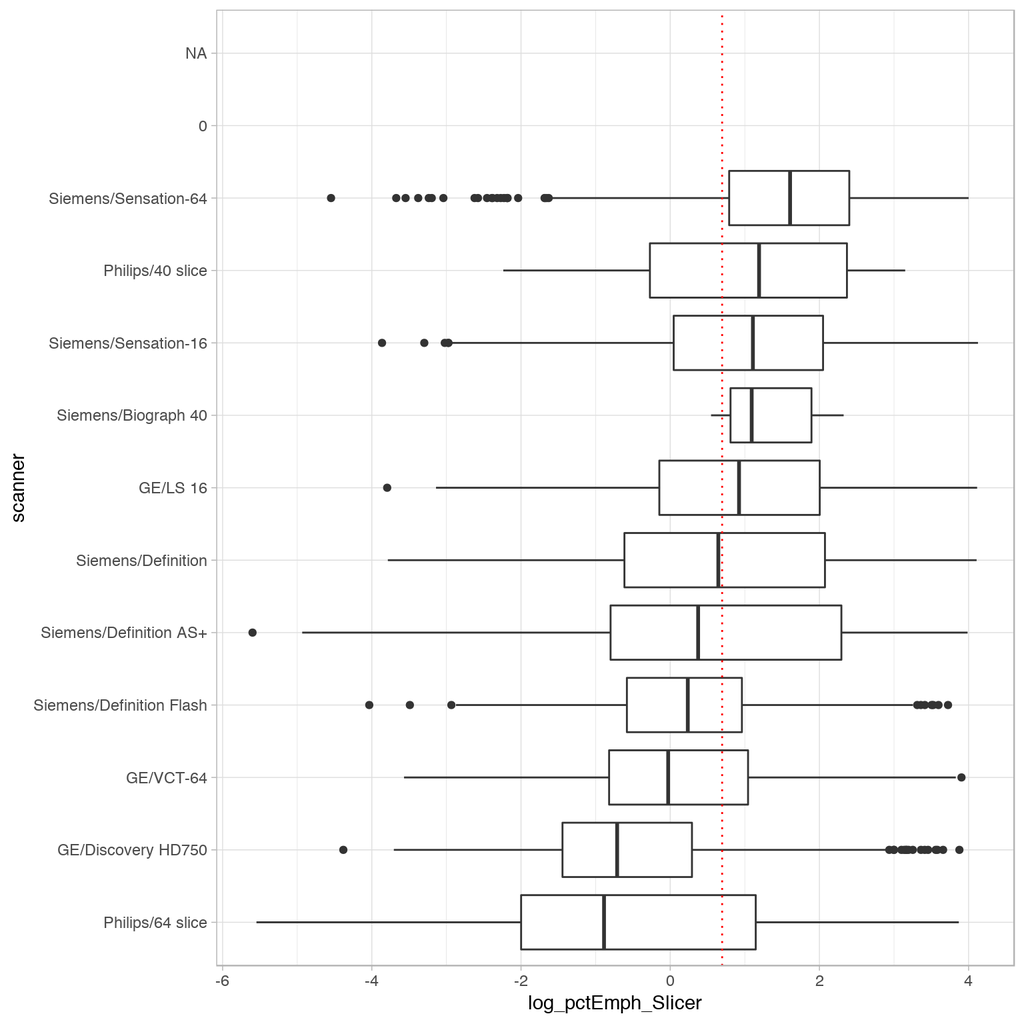

## 7.2 Global Ancestry

| Characteristic | Value |
| --- | --- |
| median | 0.83 |
| min | 0.29 |
| max | 0.99 |

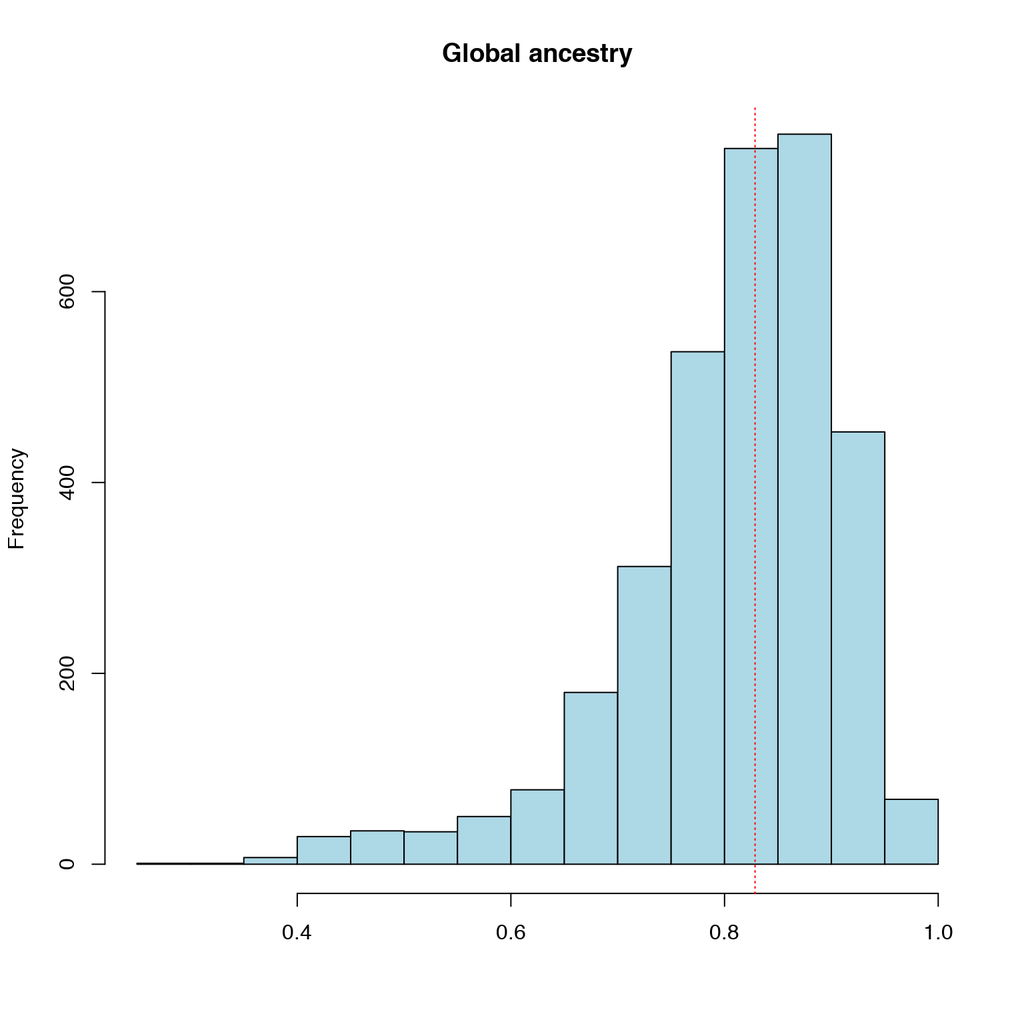

# 8 Appendix

## 8.1 All variables

sid, ccenter, distwalked, O2_suppl_6MW, Walk_Course, Walk_Limit, WalkSymp_BackPain, WalkSymp_JointPain, WalkSymp_Legs_Fatigue, WalkSymp_ShortnessBreath, QA_CalciumCalPad, scanner, FinalApproval, CTMissing_Reason, diasBP, gender, HR, O2_Hours_Day, O2_Therapy, O2_Years, Resting_SaO2, SysBP, Weight_KG, Height_CM, BMI, O2use_rest, O2use_exercise, O2use_sleep, race, ethnic, Blood_Other_Use, HealthStatus, CancerBladder, CancerBreast, CancerColon, CancerLung, CancerProstate, Angina, CongestHeartFail, CoronaryArtery, Diabetes, HighBloodPres, HighCholest, Pneumothorax, HeartAttack, BloodClots, MacularDegen, PeriphVascular, stroke, TIA, GastroEsophReflx, StomachUlcers, CompressFracBack, HipFracture, OsteoArth, Osteoporosis, RheumArth, StiffPainLimitWk, StiffPainBack, LimitWalkMost, CABG, Angioplasty, Alpha1Test, PhenoGenotype, PhenoGenoDK, PhenoGenoMGLevel, PhenoGenoMoleL, HowSoonSmoke, SmokeMore2hrs, CigHateGiveUp, FindHardNotSmoke, SmokeSickBed, SmokeMenthol, PainfulJoints, LowerBackPain, PainJointType_Shoulder, PainJointType_Elbow, PainJointType_Wrist, PainJointType_Hip, PainJointType_Knee, PainJointType_Foot, bagonist, bagonistlongact, CombcCSBagon, combivent, Cortsterinhal, CortsterOral, CurrentMedUse, ipratrop, nebulizer, theoph, tiotrop, HaveCough, Cough4Plus, CoughAM_yn, CoughRestDay, Cough3Mo, CoughNumYr, HavePhlegm, PhlegmOften, PhlegmAM, PhlegmRestDay, Phlegm3Mo, PhlegmNumYr, EpisodeCghPhlm, NumEpisodeLastYr, YrsEpisodeLast, ChstWheezyWhist, AgeWheezWhist, AgeWheezWhistDK, ShrtBrthAttk, AgeFirstAttack, AgeFirstAttackDK, ShrtBrth2Plus, MedorTreatAttack, ChestWheez12mo, WithCold, ApartFromCold, MoreOnceAWeek, MostDaysNights, AwakeByCough, AwakeByShrtBrth, SneezRunnyNose, ItchyBurningEye, UnablWalkCondOth, LtdUphill, LtdLevelSlow, LtdLevelStop, LtdLvlStop100, LtdNotLeaveHm, ERLungProb, ERLungProbtimes, TreatChestIll, TreatChestTimes, TreatSteroids, TreatSteroiTimes, FlareupChestTrb, Asthma, AsthmaAge, AsthmaAgeDK, AsthmaDxByDr, AsthmaStillHave, AsthmaAgeStop, AsthmaStopChild, AsthmaTreat, HayFev, HayFevAge, HayFevAgeDK, HayFevDxByDr, HayFevStillHave, HayFevAgeStop, HayFevStill, HayFevTreat, BronchAttack, BronchDxByDr, BronchAge, BronchAgeDK, BronchTimes, Pneumonia, PneuDxByDr, PneuAge, PneuAgeDK, PneuTimes, ChronBronch, ChronBroncDxByDr, ChronBroncAge, ChronBrncStillHv, ChronBroncTreat, Emphysema, EmphDxByDr, EmphAge, EmphStillHave, EmphTreat, COPD, CopdDxByDr, CopdAge, CopdStillHave, CopdTreat, SleepApnea, SleepApDxByDr, SleepApAge, SleepApStillHav, SleepApTreat, ChestIllOther, ChestOper, ChestInj, EverSmokedCig, SmokStartAge, SmokCigNow, CigPerDaySmokNow, SmokStopAge, CigPerDaySmokAvg, CigSmok24hrs_NA, CigSmok24hrs, CigSmok2hrs, CigSmokHalfHr, SmokPipeReg, AgeStartSmokPipe, SmokPipeNow, QtySmokPipeTob, AgeStopSmokPipe, SmokTobPerWeek, SmokCigarReg, AgeStartSmkCigar, SmokCigarNow, CigarPerDayNow, AgeStopSmokCigar, SmokCigarPerWeek, MothSmokPreg, OthSmokChildYrs, OthSmokYrs, ExpSmokAtWorkYr, SchoolCompleted, DustyJobEver, FumesJobEver, WorkNow, WorkDustyJobNow, ExpFumesNow, StopWork, FathChronBronch, MothChronBronch, FathEmphysema, MothEmphysema, FathCOPD, MothCOPD, FathAsthma, MothAsthma, FathLungCancer, MothLungCancer, FathCigSmok, MothCigSmok, MMRCDyspneaScor, COPDExacTrt1, COPDExacTrt2, COPDExacTrt3, COPDExacTrt4, COPDExacTrt5, SGRQ_scoreSymptom, SGRQ_scoreActive, SGRQ_scoreImpact, SGRQ_scoreTotal, kernel, TLC_CT, pctEmph, Insp_Below950_Vida, Insp_Below910_Vida, Insp_Below856_Vida, Vida_15perc_Insp, AttenMean_Insp, AttenStdDev_Insp, FRC_CT, pctGasTrap, Exp_Below950_Vida, Exp_Below910_Vida, Exp_Below856_Vida, Vida_15perc_Exp, AttenMean_Exp, AttenStdDev_Exp, pctEmph_UpperLobes, pctEmph_LowerLobes, pctEmph_UL_LL_ratio, UL_pctTotalAirVol, ExpInspMeanAtten_ratio, TLC_Slicer, pctEmph_Slicer, Insp_Below950_Slicer, Insp_Below910_Slicer, Insp_Below856_Slicer, Slicer_15pctIn_Total, Slicer_IntensityMean_In, Slicer_IntensityStdDev_In, FRC_Slicer, pctGasTrap_Slicer, Exp_Below950_Slicer, Exp_Below910_Slicer, Exp_Below856_Slicer, Slicer_15pctEx_Total, Slicer_IntensityMean_Ex, Slicer_IntensityStdDev_Ex, pctEmph_UpperThird_Slicer, pctEmph_LowerThird_Slicer, Slicer_ExpInspMeanAtten_ratio, UpperThird_LowerThird_Slicer, Pi10_SRWA, Pi15_SRWA, WallAreaPct_seg, WallAreaPct_subseg, SF36_PF_score, SF36_RP_score, SF36_RE_score, SF36_SF_score, SF36_BP_score, SF36_VT_score, SF36_MH_score, SF36_GH_score, SF36_PF_t_score, SF36_RP_t_score, SF36_RE_t_score, SF36_SF_t_score, SF36_BP_t_score, SF36_VT_t_score, SF36_MH_t_score, SF36_GH_t_score, SF36_PCS_score, SF36_MCS_score, Age_Enroll, TLCpred_race_adjusted, FRCpred_race_adjusted, TLCpp_race_adjusted, FRCpp_race_adjusted, BODE, ATS_PackYears, Duration_Smoking, YearsSinceQuit, PFT_CT_numdays, Severe_Exacerbations, Exacerbation_Frequency, Chronic_Bronchitis, Siemens64, Fagerstrom_Index, finalGold, pftused, FEV1pp_utah, FVCpp_utah, FEV1_FVC_utah, FEV1_utah, FEV6_utah, FVC_utah, PEF_utah, FEF2575_utah, pre_FEV1, pre_FEV6, pre_FVC, pre_FEV1_FVC, pre_PEF, pre_FEF2575, ATS_ERS, deltaFEV1, deltaFVC, BDR_pct_FEV1, BDR_pct_FVC, BDR, NewGOLD_SGRQ, Visit_Year, RandomGroupCode, log_pctEmph_Slicer

## 8.2 All variables ordered alphabetically

Age_Enroll, AgeFirstAttack, AgeFirstAttackDK, AgeStartSmkCigar, AgeStartSmokPipe, AgeStopSmokCigar, AgeStopSmokPipe, AgeWheezWhist, AgeWheezWhistDK, Alpha1Test, Angina, Angioplasty, ApartFromCold, Asthma, AsthmaAge, AsthmaAgeDK, AsthmaAgeStop, AsthmaDxByDr, AsthmaStillHave, AsthmaStopChild, AsthmaTreat, ATS_ERS, ATS_PackYears, AttenMean_Exp, AttenMean_Insp, AttenStdDev_Exp, AttenStdDev_Insp, AwakeByCough, AwakeByShrtBrth, bagonist, bagonistlongact, BDR, BDR_pct_FEV1, BDR_pct_FVC, Blood_Other_Use, BloodClots, BMI, BODE, BronchAge, BronchAgeDK, BronchAttack, BronchDxByDr, BronchTimes, CABG, CancerBladder, CancerBreast, CancerColon, CancerLung, CancerProstate, ccenter, ChestIllOther, ChestInj, ChestOper, ChestWheez12mo, ChronBrncStillHv, ChronBroncAge, ChronBroncDxByDr, ChronBronch, ChronBroncTreat, Chronic_Bronchitis, ChstWheezyWhist, CigarPerDayNow, CigHateGiveUp, CigPerDaySmokAvg, CigPerDaySmokNow, CigSmok24hrs, CigSmok24hrs_NA, CigSmok2hrs, CigSmokHalfHr, CombcCSBagon, combivent, CompressFracBack, CongestHeartFail, COPD, CopdAge, CopdDxByDr, COPDExacTrt1, COPDExacTrt2, COPDExacTrt3, COPDExacTrt4, COPDExacTrt5, CopdStillHave, CopdTreat, CoronaryArtery, Cortsterinhal, CortsterOral, Cough3Mo, Cough4Plus, CoughAM_yn, CoughNumYr, CoughRestDay, CTMissing_Reason, CurrentMedUse, deltaFEV1, deltaFVC, Diabetes, diasBP, distwalked, Duration_Smoking, DustyJobEver, EmphAge, EmphDxByDr, EmphStillHave, EmphTreat, Emphysema, EpisodeCghPhlm, ERLungProb, ERLungProbtimes, ethnic, EverSmokedCig, Exacerbation_Frequency, Exp_Below856_Slicer, Exp_Below856_Vida, Exp_Below910_Slicer, Exp_Below910_Vida, Exp_Below950_Slicer, Exp_Below950_Vida, ExpFumesNow, ExpInspMeanAtten_ratio, ExpSmokAtWorkYr, Fagerstrom_Index, FathAsthma, FathChronBronch, FathCigSmok, FathCOPD, FathEmphysema, FathLungCancer, FEF2575_utah, FEV1_FVC_utah, FEV1_utah, FEV1pp_utah, FEV6_utah, FinalApproval, finalGold, FindHardNotSmoke, FlareupChestTrb, FRC_CT, FRC_Slicer, FRCpp_race_adjusted, FRCpred_race_adjusted, FumesJobEver, FVC_utah, FVCpp_utah, GastroEsophReflx, gender, HaveCough, HavePhlegm, HayFev, HayFevAge, HayFevAgeDK, HayFevAgeStop, HayFevDxByDr, HayFevStill, HayFevStillHave, HayFevTreat, HealthStatus, HeartAttack, Height_CM, HighBloodPres, HighCholest, HipFracture, HowSoonSmoke, HR, Insp_Below856_Slicer, Insp_Below856_Vida, Insp_Below910_Slicer, Insp_Below910_Vida, Insp_Below950_Slicer, Insp_Below950_Vida, ipratrop, ItchyBurningEye, kernel, LimitWalkMost, log_pctEmph_Slicer, LowerBackPain, LtdLevelSlow, LtdLevelStop, LtdLvlStop100, LtdNotLeaveHm, LtdUphill, MacularDegen, MedorTreatAttack, MMRCDyspneaScor, MoreOnceAWeek, MostDaysNights, MothAsthma, MothChronBronch, MothCigSmok, MothCOPD, MothEmphysema, MothLungCancer, MothSmokPreg, nebulizer, NewGOLD_SGRQ, NumEpisodeLastYr, O2_Hours_Day, O2_suppl_6MW, O2_Therapy, O2_Years, O2use_exercise, O2use_rest, O2use_sleep, OsteoArth, Osteoporosis, OthSmokChildYrs, OthSmokYrs, PainfulJoints, PainJointType_Elbow, PainJointType_Foot, PainJointType_Hip, PainJointType_Knee, PainJointType_Shoulder, PainJointType_Wrist, pctEmph, pctEmph_LowerLobes, pctEmph_LowerThird_Slicer, pctEmph_Slicer, pctEmph_UL_LL_ratio, pctEmph_UpperLobes, pctEmph_UpperThird_Slicer, pctGasTrap, pctGasTrap_Slicer, PEF_utah, PeriphVascular, PFT_CT_numdays, pftused, PhenoGenoDK, PhenoGenoMGLevel, PhenoGenoMoleL, PhenoGenotype, Phlegm3Mo, PhlegmAM, PhlegmNumYr, PhlegmOften, PhlegmRestDay, Pi10_SRWA, Pi15_SRWA, PneuAge, PneuAgeDK, PneuDxByDr, Pneumonia, Pneumothorax, PneuTimes, pre_FEF2575, pre_FEV1, pre_FEV1_FVC, pre_FEV6, pre_FVC, pre_PEF, QA_CalciumCalPad, QtySmokPipeTob, race, RandomGroupCode, Resting_SaO2, RheumArth, scanner, SchoolCompleted, Severe_Exacerbations, SF36_BP_score, SF36_BP_t_score, SF36_GH_score, SF36_GH_t_score, SF36_MCS_score, SF36_MH_score, SF36_MH_t_score, SF36_PCS_score, SF36_PF_score, SF36_PF_t_score, SF36_RE_score, SF36_RE_t_score, SF36_RP_score, SF36_RP_t_score, SF36_SF_score, SF36_SF_t_score, SF36_VT_score, SF36_VT_t_score, SGRQ_scoreActive, SGRQ_scoreImpact, SGRQ_scoreSymptom, SGRQ_scoreTotal, ShrtBrth2Plus, ShrtBrthAttk, sid, Siemens64, SleepApAge, SleepApDxByDr, SleepApnea, SleepApStillHav, SleepApTreat, Slicer_15pctEx_Total, Slicer_15pctIn_Total, Slicer_ExpInspMeanAtten_ratio, Slicer_IntensityMean_Ex, Slicer_IntensityMean_In, Slicer_IntensityStdDev_Ex, Slicer_IntensityStdDev_In, SmokCigarNow, SmokCigarPerWeek, SmokCigarReg, SmokCigNow, SmokeMenthol, SmokeMore2hrs, SmokeSickBed, SmokPipeNow, SmokPipeReg, SmokStartAge, SmokStopAge, SmokTobPerWeek, SneezRunnyNose, StiffPainBack, StiffPainLimitWk, StomachUlcers, StopWork, stroke, SysBP, theoph, TIA, tiotrop, TLC_CT, TLC_Slicer, TLCpp_race_adjusted, TLCpred_race_adjusted, TreatChestIll, TreatChestTimes, TreatSteroids, TreatSteroiTimes, UL_pctTotalAirVol, UnablWalkCondOth, UpperThird_LowerThird_Slicer, Vida_15perc_Exp, Vida_15perc_Insp, Visit_Year, Walk_Course, Walk_Limit, WalkSymp_BackPain, WalkSymp_JointPain, WalkSymp_Legs_Fatigue, WalkSymp_ShortnessBreath, WallAreaPct_seg, WallAreaPct_subseg, Weight_KG, WithCold, WorkDustyJobNow, WorkNow, YearsSinceQuit, YrsEpisodeLast